# Predicting barbell lifting quality with wearable devices

justmzen

06/12/2020

# Introduction

Using devices such as Jawbone Up, Nike FuelBand, and Fitbit it is now possible to collect a large amount of data about personal activity relatively inexpensively. These type of devices are part of the quantified self movement – a group of enthusiasts who take measurements about themselves regularly to improve their health, to find patterns in their behavior, or because they are tech geeks. One thing that people regularly do is quantify how much of a particular activity they do, but they rarely quantify how well they do it. In this project, the goal is to use data from accelerometers on the belt, forearm, arm, and dumbell of 6 participants. They were asked to perform barbell lifts correctly and incorrectly in 5 different ways.

The goal of this project is to predict the manner in which a participant did the exercise. This is the “classe” variable in the training set. Any of the other variables can be used to predict with.

A report should be created describing how the model was built, how cross validation was used, the expected out of sample error and the reasons for all those choices. It is also asked to used the prediction model to predict 20 different test cases.

The data for the project come from this source: http://groupware.les.inf.puc-rio.br/har.

More information is available from the website here: http://groupware.les.inf.puc-rio.br/har (see the section on the Weight Lifting Exercise Dataset).

# Data downloading a reading

```r
if(!dir.exists('./input')) dir.create('./input')
if(!file.exists(('./input/training.csv'))){
        fileURLTraining <- 'https://d396qusza40orc.cloudfront.net/predmachlearn/pml-training.csv'
        download.file(fileURLTraining, destfile = './input/training.csv')
        rm(fileURLTraining)
}
if(!file.exists(('./input/testing.csv'))){
        fileURLTesting <- 'https://d396qusza40orc.cloudfront.net/predmachlearn/pml-testing.csv'
        download.file(fileURLTesting, destfile = './input/testing.csv')
        rm(fileURLTesting)
}
```

```r
global_training <- read.csv(file = './input/training.csv',
                            stringsAsFactors = TRUE)
validation <- read.csv(file = './input/testing.csv',
                       stringsAsFactors = TRUE)
```

# Exploratory data analysis

In order to find relevant variables we will perform a brief EDA. There are 160 variables and 19622 observations.

```r
head(global_training)[1:10]
```

```
##   X user_name raw_timestamp_part_1 raw_timestamp_part_2   cvtd_timestamp
## 1 1  carlitos           1323084231               788290 05/12/2011 11:23
## 2 2  carlitos           1323084231               808298 05/12/2011 11:23
## 3 3  carlitos           1323084231               820366 05/12/2011 11:23
## 4 4  carlitos           1323084232               120339 05/12/2011 11:23
## 5 5  carlitos           1323084232               196328 05/12/2011 11:23
## 6 6  carlitos           1323084232               304277 05/12/2011 11:23
##   new_window num_window roll_belt pitch_belt yaw_belt
## 1         no         11      1.41       8.07    -94.4
## 2         no         11      1.41       8.07    -94.4
## 3         no         11      1.42       8.07    -94.4
## 4         no         12      1.48       8.05    -94.4
## 5         no         12      1.48       8.07    -94.4
## 6         no         12      1.45       8.06    -94.4
```

We will exclude the first five variables in order to have only logical, numerical and relevant factor variables.

```r
global_training <- global_training[, -(1:5)]
validation <- validation[, -(1:5)]
```

There is also an important number of variables mostly composed by NAs. We will exclude these variables as well.

```r
emptyVariables <- sapply(X = global_training,
                         function(x) {mean(is.na(x)) > 0.8}
)

global_training <- global_training[, emptyVariables == FALSE]
validation <- validation[, emptyVariables == FALSE]

numNAVariables <- sum(emptyVariables)
```

The number of these variables is 67.

There are also variables with low variability, hence not representative of the phenomenons. We will also exclude them. The ‘caret’ package provides the ‘nearZeroVar’ function which diagnoses predictors with zero variance and predictors with few unique values compared to the number of samples.

```r
library('caret')
nearZeroVarVariables <- nearZeroVar(global_training)

global_training <- global_training[, -nearZeroVarVariables]
validation <- validation[, -nearZeroVarVariables]
```

# Cross validation

The large amount of data provided as training data let us split it into two different data sets, one used as the trainer and called “training” and the second used as the tester and called “testing”. The secondo original data set, provided for the prediction, will be called “validation”.

The partition of the original data set will be done via random sampling. A percentage fixed at 70% will form the training set and the other 30% will form the test one:

```r
set.seed(6574)
inTrain <- createDataPartition(y = global_training$classe,
                               p = 0.70, list = FALSE)

training <- global_training[inTrain, ]
testing <- global_training[-inTrain, ]
```

# Machine learning modelling

Three machine learning models will be built on the ‘training’ data set and then applied to the ‘testing’ data set. The accuracy will be calculated for each of them through confusion matrices. The machine leaning model with the highest accuracy will finally be applied to predict the ‘class’ of the ‘validation’ data set.

## 1. Decision tree

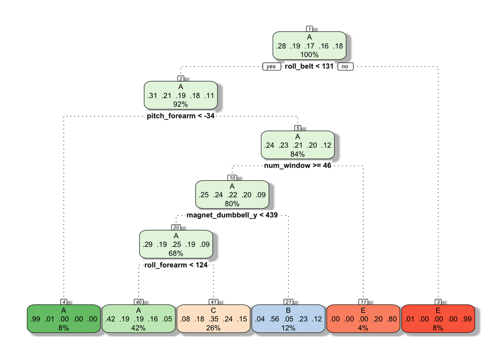

```r
# Model building
set.seed(98621)
require('e1071')
modFitDecisionTree <- train(classe ~ ., data = training,
                            method = 'rpart')

# Plot
require('rattle')
fancyRpartPlot(modFitDecisionTree$finalModel, caption = '')
```

```r
# Prediction
predictionDecisionTree <- predict(modFitDecisionTree,
                                  newdata = testing)

# Accuracy
confDecisionTree <- confusionMatrix(predictionDecisionTree,
                                    testing$classe)
confDecisionTree
```

```
## Confusion Matrix and Statistics
##
##           Reference
## Prediction    A    B    C    D    E
##          A 1528  473  483  428  108
##          B   21  377   30  196   87
##          C  118  289  513  299  215
##          D    0    0    0    0    0
##          E    7    0    0   41  672
##
## Overall Statistics
##
##                Accuracy : 0.5251
##                  95% CI : (0.5122, 0.5379)
##     No Information Rate : 0.2845
##     P-Value [Acc > NIR] : < 2.2e-16
##
##                   Kappa : 0.3797
##
##  Mcnemar's Test P-Value : < 2.2e-16
##
## Statistics by Class:
##
##                      Class: A Class: B Class: C Class: D Class: E
## Sensitivity            0.9128  0.33099  0.50000   0.0000   0.6211
## Specificity            0.6457  0.92962  0.81045   1.0000   0.9900
## Pos Pred Value         0.5060  0.53024  0.35774      NaN   0.9333
## Neg Pred Value         0.9490  0.85273  0.88475   0.8362   0.9206
## Prevalence             0.2845  0.19354  0.17434   0.1638   0.1839
## Detection Rate         0.2596  0.06406  0.08717   0.0000   0.1142
## Detection Prevalence   0.5132  0.12082  0.24367   0.0000   0.1223
## Balanced Accuracy      0.7792  0.63031  0.65523   0.5000   0.8055
```

## 2. Random forest model

```r
# Model building
set.seed(98621)
require('dplyr')
require('randomForest')
trControlRF <- trainControl(method = 'cv', number = 3, verboseIter = FALSE)
startTime <- Sys.time()
modFitRandomForest <- train(x = select(training, -classe),
                            y = as.factor(training$classe),
                            method = 'rf',
                            trControl = trControlRF)
endTime <- Sys.time()

# Prediction
predictionRandomForest <- predict(modFitRandomForest,
                                  newdata = testing)

# Accuracy
confRandomForest <- confusionMatrix(predictionRandomForest,
                                    testing$classe)
confRandomForest
```

```
## Confusion Matrix and Statistics
##
##           Reference
## Prediction    A    B    C    D    E
##          A 1674    8    0    0    0
##          B    0 1127    5    0    0
##          C    0    4 1021    2    0
##          D    0    0    0  962    3
##          E    0    0    0    0 1079
##
## Overall Statistics
##
##                Accuracy : 0.9963
##                  95% CI : (0.9943, 0.9977)
##     No Information Rate : 0.2845
##     P-Value [Acc > NIR] : < 2.2e-16
##
##                   Kappa : 0.9953
##
##  Mcnemar's Test P-Value : NA
##
## Statistics by Class:
##
##                      Class: A Class: B Class: C Class: D Class: E
## Sensitivity            1.0000   0.9895   0.9951   0.9979   0.9972
## Specificity            0.9981   0.9989   0.9988   0.9994   1.0000
## Pos Pred Value         0.9952   0.9956   0.9942   0.9969   1.0000
## Neg Pred Value         1.0000   0.9975   0.9990   0.9996   0.9994
## Prevalence             0.2845   0.1935   0.1743   0.1638   0.1839
## Detection Rate         0.2845   0.1915   0.1735   0.1635   0.1833
## Detection Prevalence   0.2858   0.1924   0.1745   0.1640   0.1833
## Balanced Accuracy      0.9991   0.9942   0.9969   0.9987   0.9986
```

```r
# Execution time
exTime <- endTime - startTime
```

## 3. Generalised boosted model

```r
# Model building
set.seed(98621)
require('gbm')
trControlGBM <- trainControl(method = 'cv', number = 4, repeats = 1)
modFitBoosting <- train(classe ~ ., data = training,
                        method = 'gbm', trControl = trControlGBM,
                        verbose = FALSE)

# Prediction
predictionBoosting <- predict(modFitBoosting,
                              newdata = testing)

# Accuracy
confBoosting <- confusionMatrix(predictionBoosting,
                                testing$classe)
confBoosting
```

```
## Confusion Matrix and Statistics
##
##           Reference
## Prediction    A    B    C    D    E
##          A 1667   14    0    0    0
##          B    7 1114    9    3    6
##          C    0   10 1014   11    2
##          D    0    1    1  949   12
##          E    0    0    2    1 1062
##
## Overall Statistics
##
##                Accuracy : 0.9866
##                  95% CI : (0.9833, 0.9894)
##     No Information Rate : 0.2845
##     P-Value [Acc > NIR] : < 2.2e-16
##
##                   Kappa : 0.983
##
##  Mcnemar's Test P-Value : NA
##
## Statistics by Class:
##
##                      Class: A Class: B Class: C Class: D Class: E
## Sensitivity            0.9958   0.9781   0.9883   0.9844   0.9815
## Specificity            0.9967   0.9947   0.9953   0.9972   0.9994
## Pos Pred Value         0.9917   0.9781   0.9778   0.9855   0.9972
## Neg Pred Value         0.9983   0.9947   0.9975   0.9970   0.9959
## Prevalence             0.2845   0.1935   0.1743   0.1638   0.1839
## Detection Rate         0.2833   0.1893   0.1723   0.1613   0.1805
## Detection Prevalence   0.2856   0.1935   0.1762   0.1636   0.1810
## Balanced Accuracy      0.9962   0.9864   0.9918   0.9908   0.9904
```

## Model selection

Based on the overall accuracies:  
- Decision tree model: 0.5250637  
- Random forest model: 0.9962617  
- Boosting model: 0.986576

The random forest model will be used for the prediction.

# Prediction

With random forest model, the predicted values for the ‘validation’ data set are:

```r
prediction <- predict(modFitRandomForest,
                newdata = validation)
prediction
```

```
##  [1] B A B A A E D B A A B C B A E E A B B B
## Levels: A B C D E
```

# Bibliografy

[1] Ugulino, W.; Cardador, D.; Vega, K.; Velloso, E.; Milidiu, R.; Fuks, H. Wearable Computing: Accelerometers’ Data Classification of Body Postures and Movements. Proceedings of 21st Brazilian Symposium on Artificial Intelligence. Advances in Artificial Intelligence - SBIA 2012. In: Lecture Notes in Computer Science. , pp. 52-61. Curitiba, PR: Springer Berlin / Heidelberg, 2012. ISBN 978-3-642-34458-9. DOI: 10.1007/978-3-642-34459-6_6.